# It's Not You, It's The Algorithm

## The Clean Datasets — What We Kept and Why

Every cleaning decision is a choice. Here's the audit trail.

From the OkCupid dataset, we removed age outliers above 80 including whoever entered 110, who we sincerely hope is doing well and filtered to single and available profiles only. The 310 married users and 2,064 "seeing someone" users were quietly removed without judgment. The resulting 57,560 profiles skew heavily educated: 37,803 have college or university degrees, 10,570 have masters degrees, and only 274 list high school as their highest qualification. OkCupid in San Francisco in 2012 was, apparently, a very specific demographic. The data will keep reminding us of this.

```python
# Initialise VADER
sia = SentimentIntensityAnalyzer()

print("Running VADER sentiment analysis on 680,608 reviews...")
print("This will take 2-3 minutes — perfect time to make a coffee.")

# Run VADER on review text
# Using vectorised approach for speed
def get_vader_score(text):
    if pd.isna(text) or text == '':
        return 0.0
    return sia.polarity_scores(str(text))['compound']

df_reviews['vader_score'] = df_reviews['Review'].apply(get_vader_score)

# VADER sentiment label
def vader_label(score):
    if score >= 0.05:
        return 'Positive'
    elif score <= -0.05:
        return 'Negative'
    else:
        return 'Neutral'

df_reviews['vader_sentiment'] = df_reviews['vader_score'].apply(vader_label)

# Also run VADER on OkCupid essay0
print("\nRunning VADER on OkCupid profiles...")
df_profiles['essay0_vader'] = df_profiles['essay0'].apply(get_vader_score)

def profile_positivity(score):
    if score >= 0.05:
        return 'Positive'
    elif score <= -0.05:
        return 'Negative'
    else:
        return 'Neutral'

df_profiles['essay0_sentiment'] = df_profiles['essay0_vader'].apply(
    profile_positivity)

# Summary stats
print("\n=== VADER COMPLETE ===\n")
print("Reviews VADER sentiment breakdown:")
print(df_reviews['vader_sentiment'].value_counts())

print(f"\nAverage VADER score by app:")
print(df_reviews.groupby('App')['vader_score'].mean().round(3))

print(f"\nAverage VADER score by rating:")
print(df_reviews.groupby('Rating')['vader_score'].mean().round(3))

print(f"\nOkCupid essay0 sentiment:")
print(df_profiles['essay0_sentiment'].value_counts())

print(f"\nAverage essay0 VADER score: {df_profiles['essay0_vader'].mean():.3f}")
```

```
Running VADER sentiment analysis on 680,608 reviews...
This will take 2-3 minutes — perfect time to make a coffee.

Running VADER on OkCupid profiles...

=== VADER COMPLETE ===

Reviews VADER sentiment breakdown:
vader_sentiment
Positive    343894
Negative    191901
Neutral     144813
Name: count, dtype: int64

Average VADER score by app:
App
Bumble   0.15
Hinge    0.23
Tinder   0.12
Name: vader_score, dtype: float64

Average VADER score by rating:
Rating
1   -0.18
2   -0.04
3    0.12
4    0.35
5    0.42
Name: vader_score, dtype: float64

OkCupid essay0 sentiment:
essay0_sentiment
Positive    47097
Neutral      8028
Negative     2435
Name: count, dtype: int64

Average essay0 VADER score: 0.700
```

## Running The Text Through VADER — What The Language Actually Says

Star ratings are what people choose when they're being measured. Review text is what people say when they're just talking. They don't always agree.

The star rating split was almost exactly even 319,690 positive versus 304,068 negative. But when VADER reads the actual language of those reviews, the picture shifts: 343,894 positive versus 191,901 negative. People write more generously than they rate. A three-star review technically neutral, is often written with language that skews positive. Someone can be frustrated enough with an app to give it three stars while still writing "I've met some really interesting people on here, the matching just needs work." The number is the complaint. The text is the hope.

And the OkCupid profiles? Average VADER score of 0.700, almost universally positive. 47,097 positive self-descriptions versus 2,435 negative ones. People are, it turns out, quite good at presenting their best selves in writing. Whether those written selves match the actual person showing up to the date is a data gap no dataset has yet been brave enough to fill.

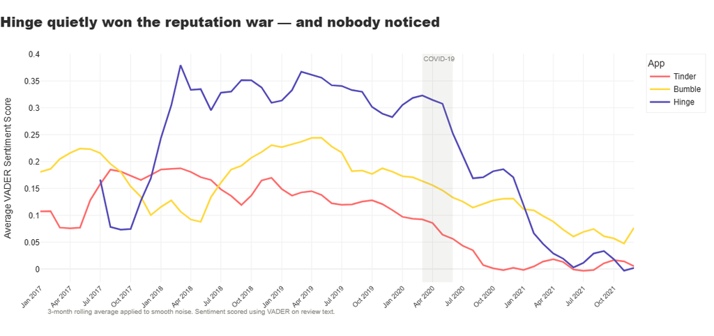

```
Chart 1 saved.
```

```python
# Filter to 2017-2022 for fair comparison
# (Hinge relaunched in 2016, so 2017 onwards is meaningful)
df_trend = df_reviews[
    (df_reviews['year'] >= 2017) &
    (df_reviews['year'] <= 2021)
].copy()

# Monthly average VADER score per app
monthly_sentiment = df_trend.groupby(
    ['App', 'year_month']).agg(
    avg_vader  = ('vader_score', 'mean'),
    avg_rating = ('Rating', 'mean'),
    review_count = ('Review', 'count')
).reset_index()

monthly_sentiment['year_month_str'] = monthly_sentiment[
    'year_month'].astype(str)

# Sort
monthly_sentiment = monthly_sentiment.sort_values(
    ['App', 'year_month_str'])

# App colours
app_colors = {
    'Tinder': '#FF6B6B',
    'Bumble': '#FFD93D',
    'Hinge' : '#534AB7'
}

fig = go.Figure()

for app in ['Tinder', 'Bumble', 'Hinge']:
    app_data = monthly_sentiment[
        monthly_sentiment['App'] == app].copy()

    # Smooth with rolling average
    app_data['smoothed'] = app_data['avg_vader'].rolling(
        window=3, min_periods=1).mean()

    fig.add_trace(go.Scatter(
        x=app_data['year_month_str'],
        y=app_data['smoothed'],
        mode='lines',
        name=app,
        line=dict(
            color=app_colors[app],
            width=2.5
        ),
        hovertemplate=(
            f"<b>{app}</b><br>"
            "Month: %{x}<br>"
            "Avg Sentiment: %{y:.3f}<extra></extra>"
        )
    ))

# Add COVID annotation
fig.add_vrect(
    x0='2020-03', x1='2020-06',
    fillcolor='rgba(136,135,128,0.1)',
    line_width=0,
    annotation_text='COVID-19',
    annotation_position='top left',
    annotation_font=dict(size=10, color='#888780')
)

fig.update_layout(
    title=dict(
        text='Hinge quietly won the reputation war — and nobody noticed',
        font=dict(size=20, color='#2d2d2d', family='Arial Black'),
        x=0, pad=dict(b=20)
    ),
    xaxis=dict(
        title='',
        gridcolor='#f0f0f0',
        tickangle=-45,
        tickfont=dict(size=10),
        nticks=20
    ),
    yaxis=dict(
        title='Average VADER Sentiment Score',
        gridcolor='#f0f0f0',
        zeroline=True,
        zerolinecolor='#f0f0f0'
    ),
    legend=dict(
        title='App',
        bordercolor='#f0f0f0',
        borderwidth=1
    ),
    plot_bgcolor='white',
    paper_bgcolor='white',
    height=500,
    margin=dict(l=60, r=40, t=80, b=80),
    font=dict(family='Arial', color='#2d2d2d')
)

fig.add_annotation(
    x=0.01, y=-0.15,
    xref='paper', yref='paper',
    text='3-month rolling average applied to smooth noise. Sentiment scored using VADER on review text.',
    showarrow=False,
    font=dict(size=10, color='#888780'),
    xanchor='left'
)

fig.write_html('charts/chart1_reputation_trajectory.html')
fig.write_image('charts/chart1_reputation_trajectory.png',
                width=1200, height=500, scale=2)

fig.show()
print("Chart 1 saved.")
```